# Question

Consider the [quadratic function](https://en.wikipedia.org/wiki/Quadratic_function) defined below.

$$f(x)~=~9x^2+3x-2$$

Below, I’ve graphed $y=f(x)$, and I’ve included the axis of symmetry as a dashed purple line and I’ve marked the distance from the axis of symmetry to one of the roots with a red line segment labelled $w$.

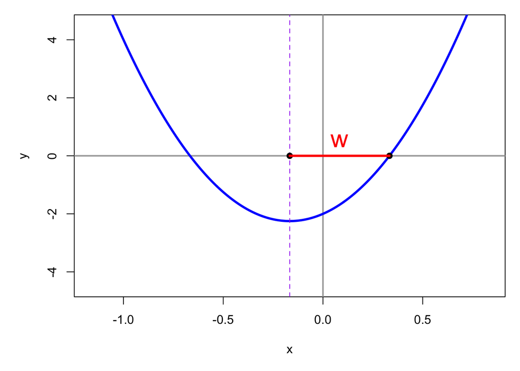

Using [the geometric significance of the quadratic formula](https://en.wikipedia.org/wiki/Quadratic_formula#Geometric_significance), calculate $w$, the distance between the axis of symmetry and one of the roots. *The tolerance is $\pm 0.01$.*

# Solution

Look at the quadratic formula, which tells us if our quadratic function is in standard form, like $y=ax^2+bx+c$, then:

$$\text{roots of quadratic function} ~=~
\frac{-b}{2a}\pm\frac{\sqrt{b^2-4ac}}{2a}$$

We were given a quadratic function in standard form. Identify the parameters.

- The quadratic coefficient: $a=9$
- The linear coefficient: $b=3$
- The constant: $c=-2$

The [the geometric significance of the quadratic formula](https://en.wikipedia.org/wiki/Quadratic_formula#Geometric_significance) tells us that $h=\frac{-b}{2a}$ and the distance of the roots to the axis of symmetry is $w=\frac{\sqrt{b^2-4ac}}{|2a|}$. Use the formula to calculate $w$.

$$w~=~\frac{\sqrt{(3)^2-4(9)(-2)}}{|2(9)|}$$

Simplify.

$$w~=~\frac{\sqrt{9+72}}{|18|}$$

Simplify.

$$w~=~\frac{\sqrt{81}}{18}$$

Use a calculator.

$$w~=~0.5$$

# Meta-information

extype: num exsolution: 0.5 exname: quad_k_from_standard extol: 0.01